# EPIB 613 INTRODUCTION TO STATISTICAL SOFTWARE

McGill EBOH

Fall 2020

Yi Lian

# Lecture 9

- More exercise on reshaping data
- Preparing for coverage probability (EPIB 607)
  - Distributions
  - `apply()`
- Coverage probability

## 1. More exercise on reshaping data

#### Change the Illinois case data (after 2020-07-12) from the long format (one row per county per day) to the wide format (one row per county with a column for each day), and back to the long format.

- Use `dplyr::pivot_wider()`, `dplyr::pivot_longer()`
- Use `my_wider()`, `my_longer()`

```r
library(covdata)
library(dplyr)
library(tidyr)
library(ggplot2)
library(readr)

pop_county <- read_csv("https://opendata.arcgis.com/datasets/21843f238cbb46b08615fc53e19e0daf_1.csv") %>%
    dplyr::rename(fips = GEOID, population = B01001_001E, state = State) %>%
    dplyr::select(state, fips, population)
county_level <- nytcovcounty %>%
    dplyr::left_join(pop_county, by = c("state","fips")) %>%
    dplyr::mutate(cases.per.10k = cases/population * 1e4) %>%
    dplyr::filter(state %in% c("Iowa","Illinois")) %>%
    dplyr::group_by(county)
# A subset that contains all dates after 2020-07-12 in Illinois
illinois <- county_level[county_level$state == "Illinois" & county_level$date >= "2020-07-12", ]
illinois[illinois$county == "Adams", ]
```

A grouped_df: 10 × 8

| date <date> | county <chr> | state <chr> | fips <chr> | cases <dbl> | deaths <dbl> | population <dbl> | cases.per.10k <dbl> |
| --- | --- | --- | --- | --- | --- | --- | --- |
| 2020-07-12 | Adams | Illinois | 17001 | 169 | 1 | 66427 | 25.44146 |
| 2020-07-13 | Adams | Illinois | 17001 | 189 | 1 | 66427 | 28.45229 |
| 2020-07-14 | Adams | Illinois | 17001 | 204 | 1 | 66427 | 30.71040 |
| 2020-07-15 | Adams | Illinois | 17001 | 208 | 1 | 66427 | 31.31257 |
| 2020-07-16 | Adams | Illinois | 17001 | 223 | 1 | 66427 | 33.57069 |
| 2020-07-17 | Adams | Illinois | 17001 | 232 | 1 | 66427 | 34.92556 |
| 2020-07-18 | Adams | Illinois | 17001 | 244 | 1 | 66427 | 36.73205 |
| 2020-07-19 | Adams | Illinois | 17001 | 252 | 1 | 66427 | 37.93638 |
| 2020-07-20 | Adams | Illinois | 17001 | 285 | 1 | 66427 | 42.90424 |
| 2020-07-21 | Adams | Illinois | 17001 | 289 | 1 | 66427 | 43.50641 |

```r
my_wider <- function(data, pivot, names_from, values_from) {

  # reorder data - to take advantage of the ordering of factors
  data <- data[order(data[, pivot]), ]
  data <- data[order(data[, names_from]), ]

  # get column names
  col.names <- unique(data[, names_from, drop = T])

  # get number of columns - one for each course
  n.col <- length(col.names)

  # generate pivot variable
  pivot.var <- unique(data[, pivot, drop = T])

  # generate number of pivots
  n.pivot <- length(pivot.var)

  # generate value matrix
  value.mat <- matrix(data[, values_from, drop = T], nrow = n.pivot, ncol = n.col, byrow = F)

  # assemble wide data frame
  data_wide <- data.frame(pivot.var, value.mat)

  # rename wide data frame
  names(data_wide) <- c(pivot, as.character(col.names))

  return(data_wide)
}

my_longer <- function(data, pivot, cols, names_to, values_to) {

  # extract the values
  values <- data[, cols]

  # change it to a vector, by column
  values <- as.vector(as.matrix(values))

  # determine number of cols
  n.col <- length(cols)

  # rep the pivot variable
  pivot.var <- rep(unlist(data[, pivot]), n.col)

  # determine the number of pivots
  n.pivot <- nrow(data)

  # make the names_to variable
  names_to.var <- rep(cols, each = n.pivot)

  # assemble long data frame
  data.long <- data.frame(pivot.var, names_to.var, values)

  # rename long data frame
  names(data.long) <- c(pivot, names_to, values_to)

  return(data.long)

}
```

```r
# Pivot_wider()
pwide <- pivot_wider(data = illinois, id_cols = county, names_from = date, values_from = cases); head(pwide)
```

A grouped_df: 6 × 11

| county <chr> | 2020-07-12 <dbl> | 2020-07-13 <dbl> | 2020-07-14 <dbl> | 2020-07-15 <dbl> | 2020-07-16 <dbl> | 2020-07-17 <dbl> | 2020-07-18 <dbl> | 2020-07-19 <dbl> | 2020-07-20 <dbl> | 2020-07-21 <dbl> |
| --- | --- | --- | --- | --- | --- | --- | --- | --- | --- | --- |
| Adams | 169 | 189 | 204 | 208 | 223 | 232 | 244 | 252 | 285 | 289 |
| Alexander | 25 | 25 | 25 | 26 | 27 | 29 | 30 | 32 | 32 | 32 |
| Bond | 22 | 22 | 22 | 21 | 23 | 24 | 24 | 26 | 25 | 28 |
| Boone | 637 | 639 | 640 | 641 | 645 | 646 | 647 | 649 | 656 | 659 |
| Brown | 10 | 10 | 10 | 10 | 10 | 10 | 10 | 11 | 11 | 11 |
| Bureau | 37 | 38 | 43 | 44 | 47 | 48 | 50 | 53 | 53 | 57 |

```r
# Pivot_longer()
plong <- pivot_longer(data = pwide, cols = contains('2020'), names_to = "Date", values_to = "Cases")
head(plong)
```

A grouped_df: 6 × 3

| county <chr> | Date <chr> | Cases <dbl> |
| --- | --- | --- |
| Adams | 2020-07-12 | 169 |
| Adams | 2020-07-13 | 189 |
| Adams | 2020-07-14 | 204 |
| Adams | 2020-07-15 | 208 |
| Adams | 2020-07-16 | 223 |
| Adams | 2020-07-17 | 232 |

```r
#
today <- as.Date("2020-10-30")
tomorrow <- as.Date("2020-10-31")
class(today)

as.numeric(today)
```

'Date'

18565

```r
# my_wider
mwide <- my_wider(data = illinois, pivot = "county", names_from = "date", values_from = "cases")
head(mwide)
```

A data.frame: 6 × 11

| county <fct> | 2020-07-12 <dbl> | 2020-07-13 <dbl> | 2020-07-14 <dbl> | 2020-07-15 <dbl> | 2020-07-16 <dbl> | 2020-07-17 <dbl> | 2020-07-18 <dbl> | 2020-07-19 <dbl> | 2020-07-20 <dbl> | 2020-07-21 <dbl> |
| --- | --- | --- | --- | --- | --- | --- | --- | --- | --- | --- |
| Adams | 169 | 189 | 204 | 208 | 223 | 232 | 244 | 252 | 285 | 289 |
| Alexander | 25 | 25 | 25 | 26 | 27 | 29 | 30 | 32 | 32 | 32 |
| Bond | 22 | 22 | 22 | 21 | 23 | 24 | 24 | 26 | 25 | 28 |
| Boone | 637 | 639 | 640 | 641 | 645 | 646 | 647 | 649 | 656 | 659 |
| Brown | 10 | 10 | 10 | 10 | 10 | 10 | 10 | 11 | 11 | 11 |
| Bureau | 37 | 38 | 43 | 44 | 47 | 48 | 50 | 53 | 53 | 57 |

```r
# my_longer
mlong <- my_longer(data = mwide, pivot = "county",
                   cols = grep(pattern = '2020', x = names(mwide)),
                   names_to = "Date", values_to = "Cases")
head(mlong)
```

A data.frame: 6 × 3

| county <fct> | Date <int> | Cases <dbl> |
| --- | --- | --- |
| Adams | 2 | 169 |
| Alexander | 2 | 25 |
| Bond | 2 | 22 |
| Boone | 2 | 637 |
| Brown | 2 | 10 |
| Bureau | 2 | 37 |

## 2. Distributions

- Probability density function (PDF) for continuous, probability mass function (PMF) for discrete
  - d*__* (dnorm, dbinom, dpois, etc..)
- Quantile
  - q*__* (qnorm, qbinom, qpois, etc..)
- Tail probability
  - p*__* (pnorm, pbinom, ppois, etc..)
- Random number
  - r*__* (rnorm, rbinom, rpois, etc..)

### 2.1 d*__*( )

#### For discrete distributions like the binomial, d*__*( ) gives the probability mass

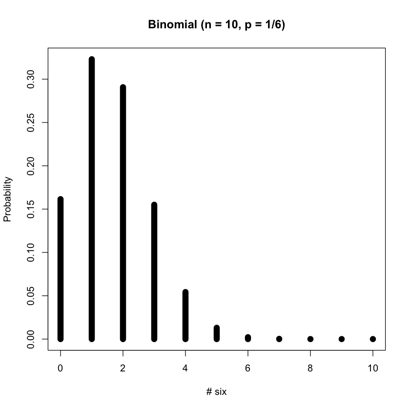

```r
# Binomial distribution

# Toss a fair dice 10 times and get 6 for X times, X ~ Binomial(10, 1/6)
six <- 0:10

plot(six, dbinom(six, size = 10, prob = 1/6),
     type = 'h',
     main = 'Binomial (n = 10, p = 1/6)',
     ylab = 'Probability',
     xlab = '# six',
     lwd = 10)
```

```r
dbinom(x = 3, size = 10, prob = 1/6)
```

0.155045359574252

##### Exercise.

1. Calculate $\mathrm{Pr}(X=3),\ X\sim\mathrm{Binomial(n=10, p=0.2)}$
2. Calculate $\mathrm{Pr}(Y=10),\ Y\sim\mathrm{Poisson(\lambda = 5, 6, 7)}$

```r
dbinom(x = 3, size = 10, prob = 0.2)
```

0.201326592

```r
dpois(x = 10, lambda = 5:7)
```

1. 0.0181327887078219

2. 0.0413030934123377

3. 0.0709832686504137

#### For continuous distributions, d*__*( ) gives the density

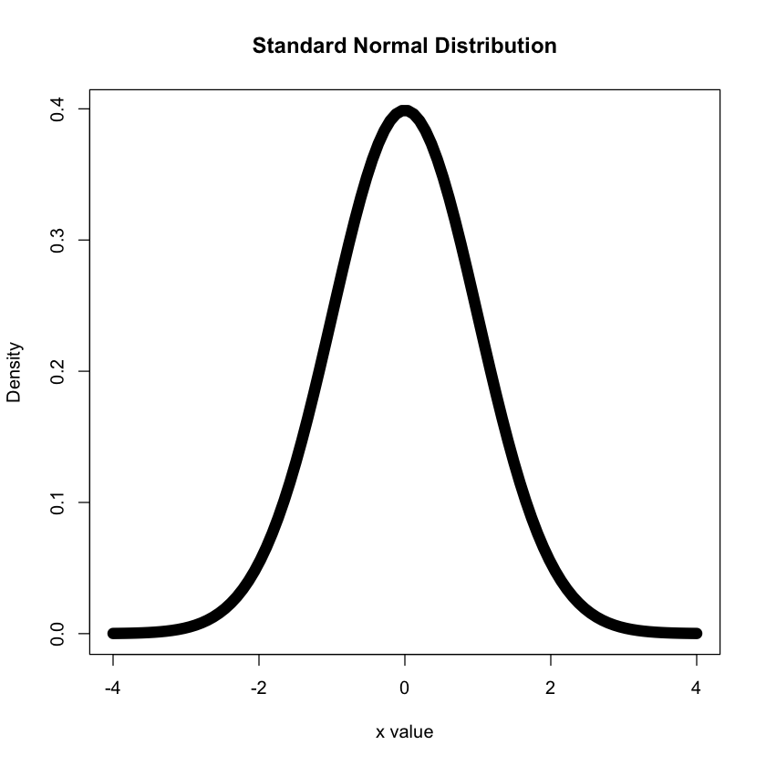

```r
x <- seq(-4, 4, length = 100)
hx <- dnorm(x)

plot(x, hx, type = "l", lwd = 10,
     xlab = "x value", ylab = "Density",
     main = "Standard Normal Distribution")
```

##### Exercise.

1. Calculate $f(X=3),\ X\sim\mathrm{Normal(\mu=10, \sigma^2=5)}$

```r
dnorm(x = 3, mean = 10, sd = sqrt(5))
```

0.00132856284397711

### 2.2 q*__*( )

#### The quantile function

**0%**

50.0000409781933

**25%**

62.5370138004655

**50%**

75.0159901275765

**75%**

87.5066237378633

**100%**

99.9999984400347

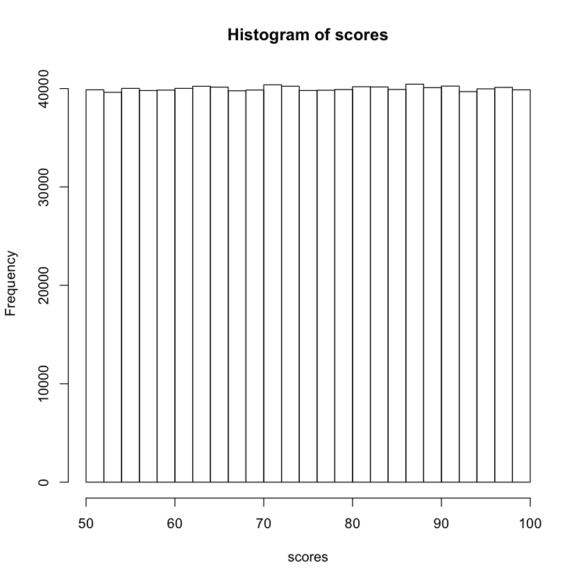

```r
# what is quantile?
set.seed(613)
# uniformly sample between 50 and 100
scores <- runif(n = 1000000, min = 50, max = 100)
hist(scores)

# The sample quantile
quantile(x = scores)
```

#### As the sample size increases, the sample distribution approaches the underlying true distribution. In this case, uniform(50, 100).

#### The q*__*( ) functions calculates the theoretical quantile of the distributions

```r
# uniform distribution
qunif(p = 0.25, min = 50, max = 100)
```

62.5

##### Exercise.

1. Calculate the 95th percentile of $\mathrm{Normal}(\mu = 5, \sigma^2 = 4)$
2. Calculate the 2.5th percentile of a standard normal distribution

```r
qnorm(p = .95, mean = 5, sd = 2)
```

8.28970725390294

```r
qnorm(p = 0.025)
```

-1.95996398454005

### 2.3 p*__*( )

#### Tail probabilities

Cumulative distribution function (CDF) or 1 - CDF

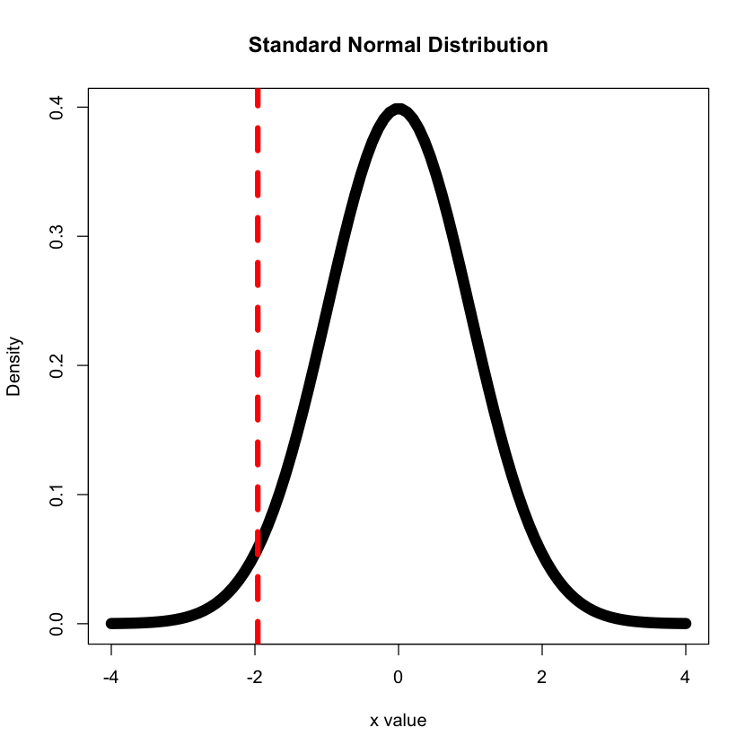

```r
x <- seq(-4, 4, length = 100)
hx <- dnorm(x)

plot(x, hx, type = "l", lwd = 10,
     xlab = "x value", ylab = "Density",
     main = "Standard Normal Distribution")

abline(v = qnorm(p = 0.025,
                 mean = 0,
                 sd = 1,
                 lower.tail = T),
       lwd = 5, col = 'red', lty = 2)
```

#### The CDF - the area under the curve to the left of the red line is 0.025.

```r
pnorm(q = -1.95996398454005, mean = 0, sd = 1, lower.tail = T)
```

0.0250000000000002

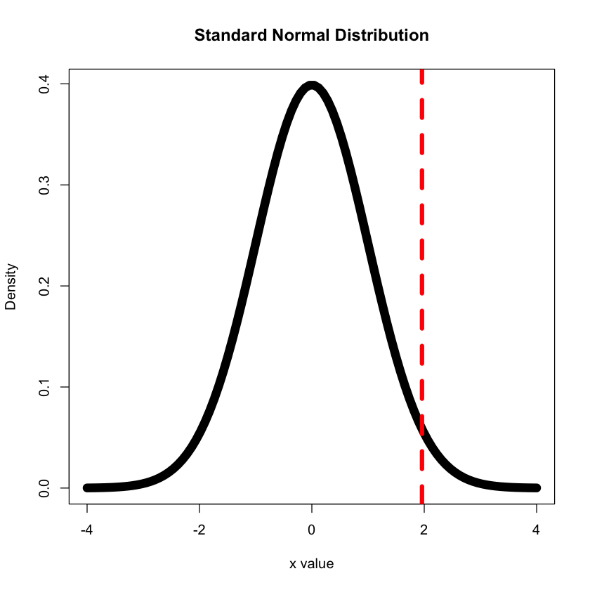

```r
plot(x, hx, type = "l", lwd = 10,
     xlab = "x value", ylab = "Density",
     main = "Standard Normal Distribution")

abline(v = qnorm(p = 0.025,
                 mean = 0,
                 sd = 1,
                 lower.tail = F),
       lwd = 5, col = 'red', lty = 2)
```

```r
pnorm(q = -1.95996398454005, mean = 0, sd = 1, lower.tail = F)
```

0.975

##### Exercise.

1. Reproduce the above plot with the argument 'lower.tail = TRUE'

### 2.4 r*__*( )

#### Random number generator, according to the distribution

```r
pois.sample <- rpois(n = 5, lambda = 6)
pois.sample
```

1. 7

2. 9

3. 7

4. 10

5. 3

```r
norm.sample <- rnorm(n = 5, mean = 1, sd = 3)
norm.sample
```

1. -0.260842892131349

2. -0.871547727860063

3. 1.19363547891603

4. 4.53110744642776

5. 0.249686729636388

```r
# seed - for reproducible random number generation
set.seed(613)
rnorm(n = 4, mean = 1, sd = 3)
rgamma(n = 3, shape = 2, rate = 3)
rgamma(n = 3, shape = 2, rate = 3)
```

1. 7.07917484171515

2. -2.78282411561524

3. -0.360856314999762

4. 1.46828151452414

1. 0.198792495552681

2. 0.364660199375798

3. 0.605962707366764

1. 0.243824482712056

2. 0.0905185592369703

3. 0.899075003186018

```r
set.seed(613)
rnorm(n = 3, mean = 1, sd = 3)
rgamma(n = 2, shape = 2, rate = 3)
rgamma(n = 2, shape = 2, rate = 3)
```

1. 7.07917484171515

2. -2.78282411561524

3. -0.360856314999762

1. 0.565755483113113

2. 0.198792495552681

1. 0.364660199375798

2. 0.605962707366764

## 3. The `apply()` family

- `apply()`
- `lapply()`
- `tapply()`
- `sapply()`
- `vapply()`
- `mapply()`

#### There are similar ones in the package `plyr`

- `adply()`
- `ddply()`
- `ldply()`
- ...

### 3.1 `apply()`

```r
mat <- matrix(1:6, nrow = 2); mat
```

A matrix: 2 × 3 of type int

| 1 | 3 | 5 |
| --- | --- | --- |
| 2 | 4 | 6 |

```r
apply(mat, MARGIN = 1, FUN = sum)
```

1. 9

2. 12

```r
apply(mat, MARGIN = 2, FUN = sum)
```

1. 3

2. 7

3. 11

```r
myarray <- array(1:12, dim = c(2,3,2)); print(myarray)
```

```
, , 1

     [,1] [,2] [,3]
[1,]    1    3    5
[2,]    2    4    6

, , 2

     [,1] [,2] [,3]
[1,]    7    9   11
[2,]    8   10   12
```

```r
apply(myarray, MARGIN = 1, FUN = sum)
```

1. 36

2. 42

```r
# What happened?
apply(myarray, MARGIN = c(1, 3), FUN = sum)
```

A matrix: 2 × 2 of type int

| 9 | 27 |
| --- | --- |
| 12 | 30 |

### 3.2 `lapply()`

list apply

```r
set.seed(613)
scores <- round(runif(n = 20, min = 50, max = 100)); scores
```

1. 99

2. 98

3. 55

4. 91

5. 66

6. 97

7. 78

8. 95

9. 59

10. 72

11. 81

12. 68

13. 70

14. 62

15. 80

16. 85

17. 61

18. 64

19. 52

20. 54

```r
groups <- cut(scores,
              breaks = c(50, 65, 70, 75, 80, 85, 100),
              labels = c("C+", "B-", "B", "B+", "A-", "A"))
groups
```

1. A

2. A

3. C+

4. A

5. B-

6. A

7. B+

8. A

9. C+

10. B

11. A-

12. B-

13. B-

14. C+

15. B+

16. A-

17. C+

18. C+

19. C+

20. C+

**Levels**:**

1. 'C+'

2. 'B-'

3. 'B'

4. 'B+'

5. 'A-'

6. 'A'

```r
score.list <- split(scores, f = groups)
score.list$A[5] <- NA
score.list
```

**$`C+`**

1. 55

2. 59

3. 62

4. 61

5. 64

6. 52

7. 54

**$`B-`**

1. 66

2. 68

3. 70

**$B**

72

**$`B+`**

1. 78

2. 80

**$`A-`**

1. 81

2. 85

**$A**

1. 99

2. 98

3. 91

4. 97

5. <NA>

```r
# Average for each letter grade
lapply(score.list, FUN = mean)
```

**$`C+`**

58.1428571428571

**$`B-`**

68

**$B**

72

**$`B+`**

79

**$`A-`**

83

**$A**

<NA>

```r
lapply(score.list, FUN = mean, na.rm = T)
```

**$`C+`**

58.1428571428571

**$`B-`**

68

**$B**

72

**$`B+`**

79

**$`A-`**

83

**$A**

96.25

### 3.3 `sapply()`

```r
# sapply a list
sapply(score.list, FUN = mean)
```

**C+**

58.1428571428571

**B-**

68

**B**

72

**B+**

79

**A-**

83

**A**

<NA>

```r
sapply(score.list, FUN = mean, na.rm = T, simplify = F)
```

**$`C+`**

58.1428571428571

**$`B-`**

68

**$B**

72

**$`B+`**

79

**$`A-`**

83

**$A**

96.25

```r
# sapply() a data frame
head(iris)
sapply(iris, FUN = class)
```

A data.frame: 6 × 5

| Sepal.Length <dbl> | Sepal.Width <dbl> | Petal.Length <dbl> | Petal.Width <dbl> | Species <fct> |
| --- | --- | --- | --- | --- |
| 5.1 | 3.5 | 1.4 | 0.2 | setosa |
| 4.9 | 3.0 | 1.4 | 0.2 | setosa |
| 4.7 | 3.2 | 1.3 | 0.2 | setosa |
| 4.6 | 3.1 | 1.5 | 0.2 | setosa |
| 5.0 | 3.6 | 1.4 | 0.2 | setosa |
| 5.4 | 3.9 | 1.7 | 0.4 | setosa |

**Sepal.Length**

'numeric'

**Sepal.Width**

'numeric'

**Petal.Length**

'numeric'

**Petal.Width**

'numeric'

**Species**

'factor'

```r
# sapply a vector
sapply(c(6, 1, 3), FUN = seq)
```

1. 1. 1

   2. 2

   3. 3

   4. 4

   5. 5

   6. 6

2. 1

3. 1. 1

   2. 2

   3. 3

```r
sapply(c(6, 1, 3), FUN = '+', 2)
```

1. 8

2. 3

3. 5

```r
# use our own function in FUN
sapply(c(6, 1, 3), FUN = function(x) {x + 2})
```

1. 8

2. 3

3. 5

```r
# plyr::ldply
plyr::ldply(`.data` = c(6, 1, 3), `.fun` = function(x) {x + 2})
```

A data.frame: 3 × 1

| V1 <dbl> |
| --- |
| 8 |
| 3 |
| 5 |

##### Exercise.

1. Use `plyr::ldply`, find out how many students there are in each letter grade.

```r
score.list
```

**$`C+`**

1. 55

2. 59

3. 62

4. 61

5. 64

6. 52

7. 54

**$`B-`**

1. 66

2. 68

3. 70

**$B**

72

**$`B+`**

1. 78

2. 80

**$`A-`**

1. 81

2. 85

**$A**

1. 99

2. 98

3. 91

4. 97

5. <NA>

### 3.4 `tapply()`

```r
# recall aggregate()
aggregate(Sepal.Length~Species, FUN = mean, data = iris)
```

A data.frame: 3 × 2

| Species <fct> | Sepal.Length <dbl> |
| --- | --- |
| setosa | 5.006 |
| versicolor | 5.936 |
| virginica | 6.588 |

```r
# Alternative syntax
aggregate(iris$Sepal.Length, by = list(Species = iris$Species), FUN = mean)
```

A data.frame: 3 × 2

| Species <fct> | x <dbl> |
| --- | --- |
| setosa | 5.006 |
| versicolor | 5.936 |
| virginica | 6.588 |

```r
tapply(X = iris$Sepal.Length, INDEX = list(Species = iris$Species), FUN = mean)
```

**setosa**

5.006

**versicolor**

5.936

**virginica**

6.588

```r
# Another function that does the same thing
by(data = iris$Sepal.Length, INDICES = list(Species = iris$Species), FUN = mean)
```

```
Species: setosa
[1] 5.006
------------------------------------------------------------
Species: versicolor
[1] 5.936
------------------------------------------------------------
Species: virginica
[1] 6.588
```

## 4. Coverage probability (EPIB 607)